# Expected cost-effectiveness of PPE for respiratory pandemics in LMICs

Sebastian Quaade and ChatGPT

2025-10-31

# 1 1. Overview

**Goal**: Crudely estimate the cost-effectiveness (CE) of LMIC PPE stockpiling to prepare for zoonotic respiratory pandemics, measured in terms dollars per healthcare worker (HCW) life saved per year.

Main ingredients:

- Baseline cost-effectiveness of PPE during COVID-19: $4,309 per HCW life ([Risko et al.](https://journals.plos.org/plosone/article?id=10.1371/journal.pone.0240503))[^1].
- Pandemic severity *s* measured as deaths per 10,000 population.
- Annual risk that a respiratory pandemic of severity *s* or more emerges. This is also known as the *exceedance function*, and is denoted by $E(s)=Pr(S≥s)$ ([Madhav et al.](https://journals.plos.org/plosone/article?id=10.1371/journal.pone.0240503)).

To avoid taking the expectation over an reciprocal, we work with lives per dollar (LPD), rather than dollars per healthcare worker lives. We define a conservative scaling for healthcare worker lives saved per dollar as a function of severity S: - For $S \leq S_{COVID}$: linear improvement with S. - For $S > S_{COVID}$: square-root improvement with S.

Formally, this is
$$\text{LPD}(S) =
\begin{cases}
\text{LPD}_{\text{COVID}} \displaystyle\frac{S}{S_{\text{COVID}}}, &
S \le S_{\text{COVID}}, \\[10pt]
\text{LPD}_{\text{COVID}}
\displaystyle\sqrt{\frac{S}{S_{\text{COVID}}}}, & S >
S_{\text{COVID}}.
\end{cases}$$

This tempers the effectiveness of PPE in extremely severe pandemics.

We calculate $ per expected life saved per year as $\frac{1}{\mathbb{E}[\text{LPD}_year]}$. Note that this is not the same as expected dollars per life saved per year, due to the nonlinearity of taking the reciprocal.

Then, assuming PPE can be stockpiled for ten years, I we integrate cost-effectiveness of stockpiles over a ten-year horizon using a discount rate $\beta=0.03$, i.e.

$$\text{LPD}_{10\,\text{years}} =
\sum_{t=0}^9 \frac{\text{LPD}_{\text{year}}}{(1+\beta)^t}$$
.

This assumes the independence of annual exceedance risks; I have not thought carefully about how problematic this assumption might be. Note that I do not account for the cost of maintaining the stockpile.

# 2 2. Inputs

```r
CE_COVID_dollars_per_life <- 4309
LPD_COVID <- 1 / CE_COVID_dollars_per_life
severity_COVID <- 14.86e6 / (7.86e9 / 1e4)

T_years <- 10
discount_rate <- 0.03

LPD_COVID; severity_COVID; T_years; discount_rate
```

```
## [1] 0.0002320724
```

```
## [1] 18.90585
```

```
## [1] 10
```

```
## [1] 0.03
```

# 3 3. Exceedance data (Madhav et al.)

```r
mraw <- read_csv("../data/raw/madhav_et_al_figure_4_digitized.csv", show_col_types = FALSE)
mx <- mraw[-1, c(1, 2)]
colnames(mx) <- c("deaths_per_10k", "annual_risk_percent")

mx <- mx %>%
  mutate(
    deaths_per_10k = as.numeric(deaths_per_10k),
    annual_risk    = as.numeric(annual_risk_percent) / 100
  ) %>%
  arrange(deaths_per_10k)
```

# 4 4. Fit a smooth exceedance E(d)

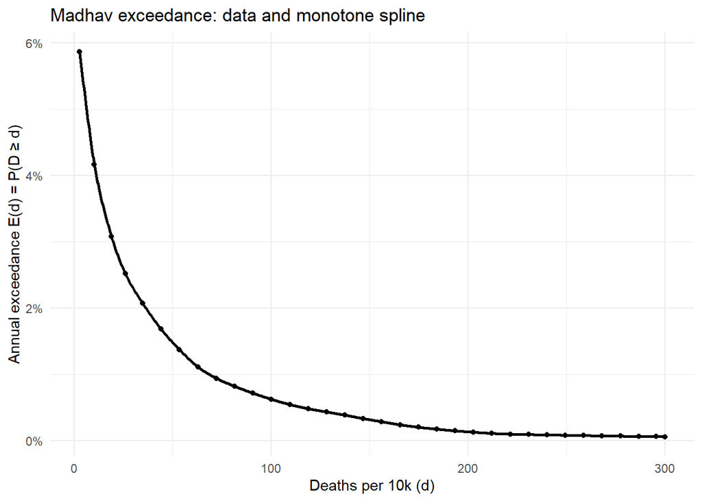

```r
severity_grid <- seq(min(mx$deaths_per_10k), max(mx$deaths_per_10k), length.out = 1000)
E_spline <- splinefun(x = mx$deaths_per_10k, y = mx$annual_risk, method = "monoH.FC")
E_grid <- E_spline(severity_grid)

ggplot() +
  geom_point(data = mx, aes(deaths_per_10k, annual_risk), size = 1.5) +
  geom_line(aes(severity_grid, E_grid), linewidth = 1) +
  scale_y_continuous(labels = percent_format(accuracy = 1)) +
  labs(x = "Deaths per 10k (d)", y = "Annual exceedance E(d) = P(D ≥ d)",
       title = "Madhav exceedance: data and monotone spline") +
  theme_minimal()
```

# 5 5. Define LPD(D): conservative scaling

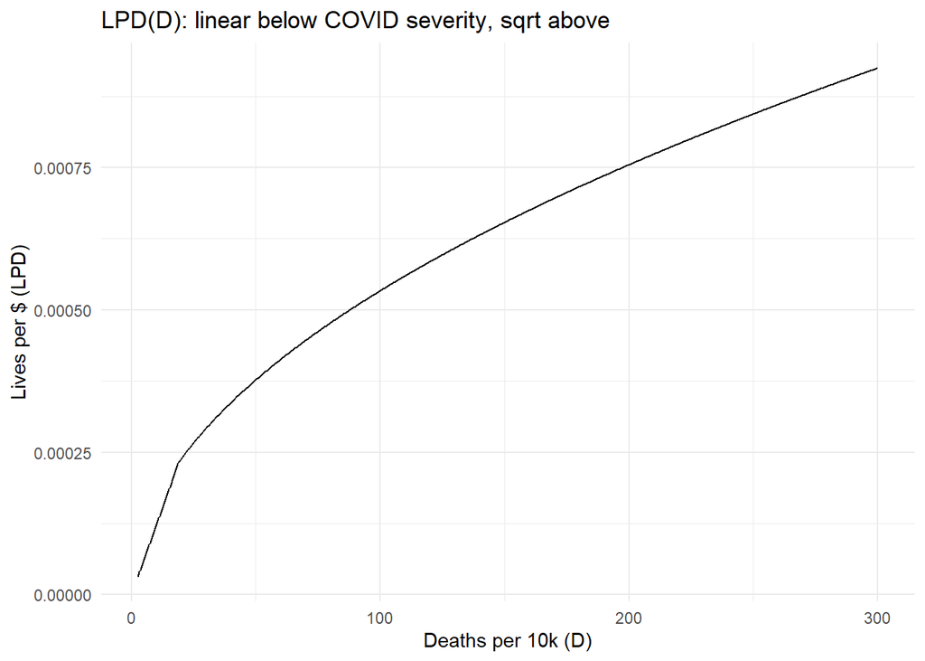

```r
LPD_at_severity <- function(severity, LPD_covid = LPD_COVID, severity_covid = severity_COVID) {
  ifelse(
    severity <= severity_covid,
    LPD_covid * (severity / severity_covid),
    LPD_covid * sqrt(severity / severity_covid)
  )
}

ggplot(data.frame(severity = severity_grid)) +
  geom_line(aes(severity, LPD_at_severity(severity))) +
  labs(x = "Deaths per 10k (D)", y = "Lives per $ (LPD)",
       title = "LPD(D): linear below COVID severity, sqrt above") +
  theme_minimal()
```

# 6 6. Unconditional pdf and annual event probability

```r
dE <- gradient(E_grid, severity_grid)
f_uncond <- -dE
p_event <- trapz(severity_grid, f_uncond)
p_event
```

```
## [1] 0.05807458
```

# 7 7. Unconditional CE per year

```r
LPD_grid <- LPD_at_severity(severity_grid)
LPD_year <- trapz(severity_grid, LPD_grid * f_uncond)
CE_uncond_per_year <- 1 / LPD_year

data.frame(
  annual_event_probability = p_event,
  lives_per_dollar_per_year = LPD_year,
  dollars_per_life_per_year = CE_uncond_per_year
)
```

```
##   annual_event_probability lives_per_dollar_per_year dollars_per_life_per_year
## 1               0.05807458              1.545285e-05                  64712.97
```

# 8 8. Aggregate over T years (with discounting)

```r
beta <- 1 / (1 + discount_rate)
weights <- beta^(0:(T_years - 1))
PV_lives   <- sum(weights * LPD_year)
CE_uncond_Tyear <- 1 / PV_lives

PV_lives; CE_uncond_Tyear
```

```
## [1] 0.0001357705
```

```
## [1] 7365.373
```

# 9 9. Notes

Sources: - PPE cost-effectiveness of PPE in LMICs during COVID-19: [Risko et al. 2020](https://journals.plos.org/plosone/article/file?id=10.1371/journal.pone.0240503&type=printable) - Pandemic mortality exceedance curve: Madhav et al. [Madhav et al. 2023](https://www.cgdev.org/publication/estimated-future-mortality-pathogens-epidemic-and-pandemic-potential). - COVID severity proxy: WHO excess deaths 2020–2021([Msemburi et al. 2023](https://pubmed.ncbi.nlm.nih.gov/36517599/)) and 2020 global population ([World Bank](https://pubmed.ncbi.nlm.nih.gov/36517599/)).

[^1]: [Risko et al.](https://journals.plos.org/plosone/article?id=10.1371/journal.pone.0240503) estimate benefits over a 30-week period, rather than a full year.